# How to create a US map with color indication

Huawen Sun

2019/06/05

## Packages needed:

#### ggplot2

## Data needed:

Any data with state names will work for this plot, but the column name for the state names must be ‘state’ or ‘fips’. For example, I am using a US home sale price data for all states, which contains state names.

## Creating the basic map

First step is to create a basic map that uses value as color indication.

For example:

```
plot_usmap(data = TopData, values = "10-Jan", lines = "white")
```

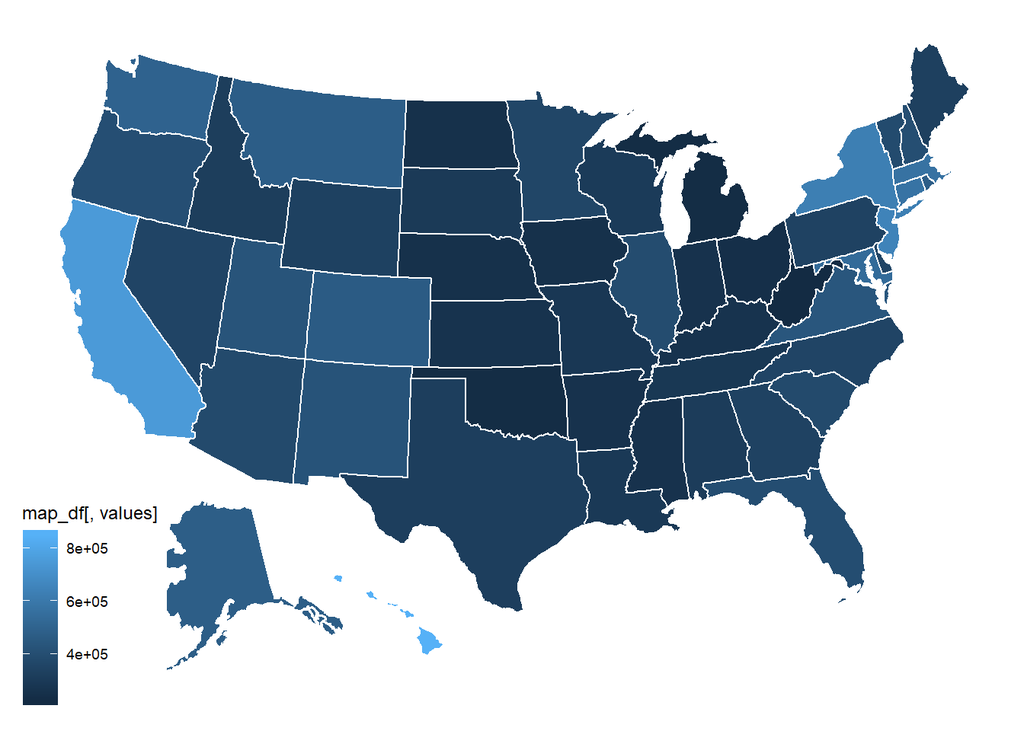

```
plot_usmap(data = TopData, values = "10-Jan", lines = "red")
```

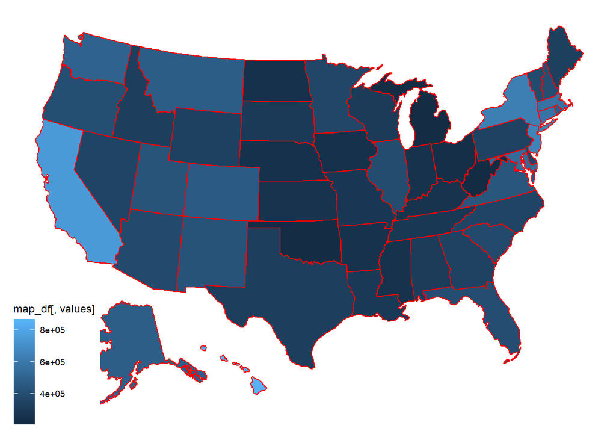

Now the color of lines are red.

## Add legend

To add legend, you can use

```
scale_fill_continuous(name = "price of 2010-01", label = scales::comma)
```

We are naming the legend as ‘price of 2010-01’, and set the scale of legend color to the price values.

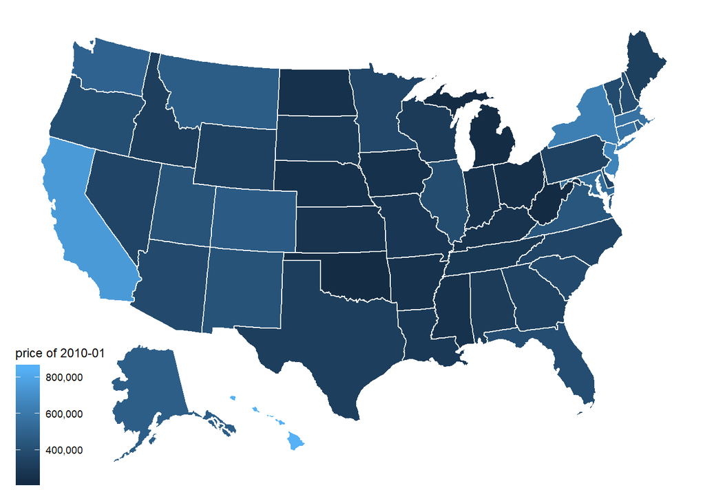

If you want to change the postion of the legend, you can type:

```
theme(legend.position = "right")
```

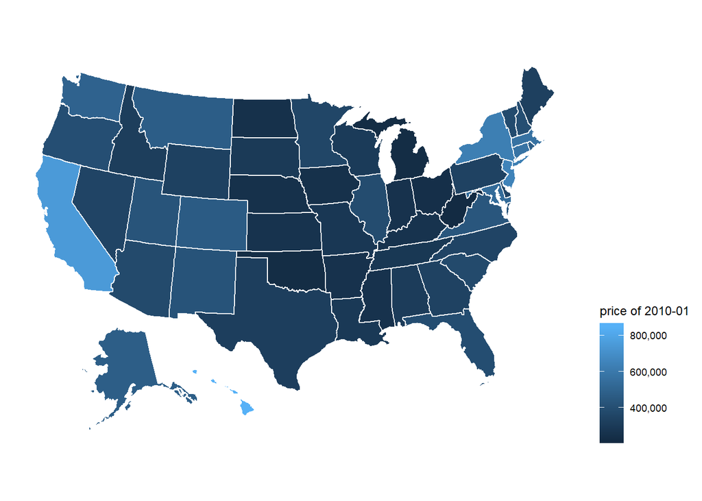

Now the legend is placed at the right side of the map.

## Add titles

You can also add title and subtitle to the map.

```
labs(title = "US home sale price 01/2010", subtitle = "Color indicates the price")
```

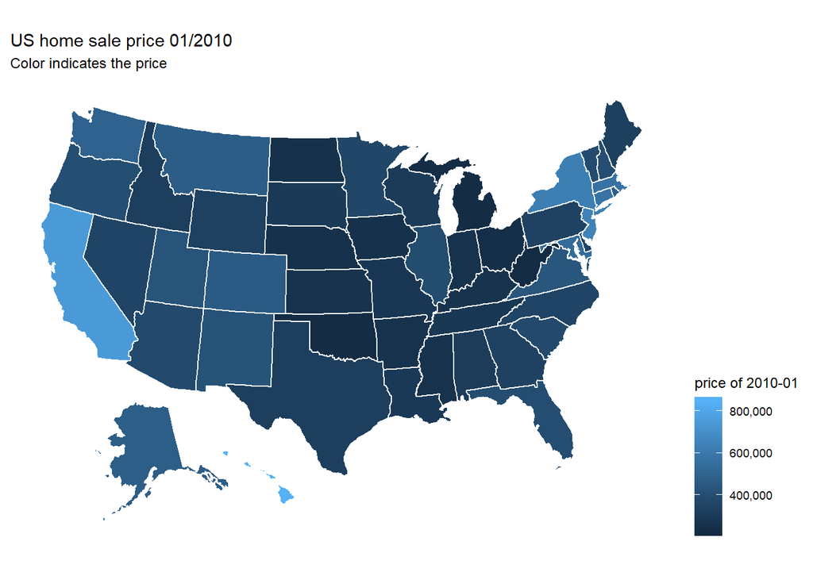

## Complete Code

```
library(data.table)
library(usmap)
library(ggplot2)

TopData <- fread("./data/State_MedianListingPrice_TopTier.csv")

colnames(TopData)[1] <- "state"

plot_usmap(data = TopData, values = "10-Jan", lines = "white") +
  scale_fill_continuous(name = "price of 2010-01", label = scales::comma) +
  theme(legend.position = "right") +
  labs(title = "US home sale price 01/2010", subtitle = "Color indicates the price")
```

## Part of TopData

### State name and 2010-01 price

```
##  [1] "Alabama"              "Alaska"               "Arizona"
##  [4] "Arkansas"             "California"           "Colorado"
##  [7] "Connecticut"          "Delaware"             "District of Columbia"
## [10] "Florida"              "Georgia"              "Hawaii"
## [13] "Idaho"                "Illinois"             "Indiana"
## [16] "Iowa"                 "Kansas"               "Kentucky"
## [19] "Louisiana"            "Maine"                "Maryland"
## [22] "Massachusetts"        "Michigan"             "Minnesota"
## [25] "Mississippi"          "Missouri"             "Montana"
## [28] "Nebraska"             "Nevada"               "New Hampshire"
## [31] "New Jersey"           "New Mexico"           "New York"
## [34] "North Carolina"       "North Dakota"         "Ohio"
## [37] "Oklahoma"             "Oregon"               "Pennsylvania"
## [40] "Rhode Island"         "South Carolina"       "South Dakota"
## [43] "Tennessee"            "Texas"                "Utah"
## [46] "Vermont"              "Virginia"             "Washington"
## [49] "West Virginia"        "Wisconsin"            "Wyoming"
```

```
##  [1] 309900 476500 379364 259900 750000 465000 575000 349900 739900 396000
## [11] 339500 850000 319000 389000 259900 249900 264000 265000 295000 329000
## [21] 539900 569900 229000 359900 259900 285000 475000 250000 349900 400000
## [31] 647900 425000 629000 349900 250000 243120 230000 402000 339900 479400
## [41] 379000 299900 286950 319900 430272 386500 440000 499000 220000 305000
## [51] 335000
```